# OrthoFinder tutorial for BUG

## The count of genes per **Orthogroup** predicted by OrthoFinder

> Location: `/raid1/home/bpp/tabimaj/orthofinder_test/OrthoFinder/Results_Feb06_1/Orthogroups/Orthogroups.GeneCount.tsv`

The **Statistics per Species** and **Statistics Overall** files provided us with a general view of the contribution of each genome and each orthogroup into our orthology analysis. For a more detailed look into our results, we should look at the **Orthogroups GeneCount** file This file includes the number of genes per species that are grouped inside each predicted orthogroup (OG).

Lets take a look at the first 5 rows of the file:

```r
og.gene_count <- read.table("Results/Orthogroups.GeneCount.tsv", header = T)

head(og.gene_count) %>% knitr::kable() %>%
 kable_styling(bootstrap_options = c("striped", "hover", "condensed", "responsive"))
```

| Orthogroup | Amanita_muscaria | Arabidopsis_thaliana | Canis_lupus | Dyctiostelium_discoideum | Paramecium_tetraurelia | Phytophthora_infestans | Total |
| --- | --- | --- | --- | --- | --- | --- | --- |
| OG0000000 | 238 | 0 | 0 | 0 | 0 | 0 | 238 |
| OG0000001 | 1 | 234 | 0 | 0 | 0 | 1 | 236 |
| OG0000002 | 200 | 0 | 0 | 0 | 0 | 2 | 202 |
| OG0000003 | 2 | 24 | 0 | 15 | 0 | 84 | 125 |
| OG0000004 | 2 | 46 | 35 | 10 | 5 | 20 | 118 |
| OG0000005 | 0 | 117 | 0 | 0 | 0 | 0 | 117 |

The results of the **Orthogroups GeneCount** file are sorted by number of total genes per orthogroup. These results show that the contributions of each species into each orthogroup are quite different. For OG0000000 we see all genes (238 genes) are contributed by *Amanita muscaria*. This is a **Single species orthogroup**.

We can observe the general pattern of the orthogroups by plotting a heat map for the first 200 orthogroups without the `Total` column

```r
library(vcfR)
```

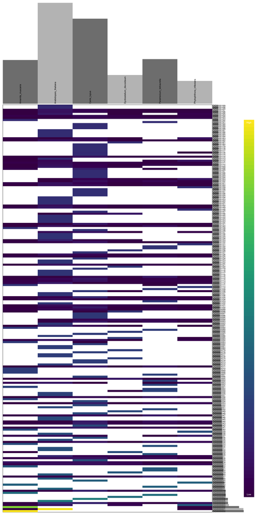

```r
OG.mtrix <- as.matrix(og.gene_count[c(1:200),-c(1,8)])
rownames(OG.mtrix) <- og.gene_count[c(1:200),1]
OG.mtrix[OG.mtrix == 0] <- NA
heatmap.bp(OG.mtrix)
```

Several things can be concluded from that figure. First, that the distribution of species that contribute in each OG is patchy. Second, that for the first 200 OG, the species that contribute the most genes are *A. thaliana* and *C. lupus*. Third, that there are some OG that have genes in every species. When we review the results of the **Statistics Overall** table, we remember that 1319 OG have all species present. We should be able to see the contributions of each species per OG by removing all OG with values of 0 and counting the remaining OG:

```r
non_zero_OG <- og.gene_count[apply(og.gene_count[,-1], 1, function (x) sum(x == 0) == 0),]
nrow(non_zero_OG)
```

```
## [1] 1319
```

Woohoo! Lets see the first 10 rows of the OG with all species:

```r
head(non_zero_OG, n=10) %>% knitr::kable() %>%
 kable_styling(bootstrap_options = c("striped", "hover", "condensed", "responsive"))
```

|  | Orthogroup | Amanita_muscaria | Arabidopsis_thaliana | Canis_lupus | Dyctiostelium_discoideum | Paramecium_tetraurelia | Phytophthora_infestans | Total |
| --- | --- | --- | --- | --- | --- | --- | --- | --- |
| 5 | OG0000004 | 2 | 46 | 35 | 10 | 5 | 20 | 118 |
| 11 | OG0000010 | 6 | 7 | 35 | 8 | 29 | 15 | 100 |
| 18 | OG0000017 | 8 | 9 | 10 | 10 | 32 | 14 | 83 |
| 24 | OG0000023 | 10 | 18 | 19 | 13 | 7 | 13 | 80 |
| 25 | OG0000024 | 24 | 18 | 20 | 14 | 2 | 1 | 79 |
| 27 | OG0000026 | 8 | 19 | 24 | 6 | 16 | 5 | 78 |
| 35 | OG0000034 | 3 | 12 | 20 | 3 | 21 | 15 | 74 |
| 42 | OG0000041 | 5 | 20 | 31 | 2 | 11 | 3 | 72 |
| 44 | OG0000043 | 4 | 7 | 34 | 7 | 11 | 7 | 70 |
| 45 | OG0000044 | 2 | 2 | 28 | 5 | 19 | 14 | 70 |

What about the last 10 rows?

```r
tail(non_zero_OG, n=10) %>% knitr::kable() %>%
 kable_styling(bootstrap_options = c("striped", "hover", "condensed", "responsive"))
```

|  | Orthogroup | Amanita_muscaria | Arabidopsis_thaliana | Canis_lupus | Dyctiostelium_discoideum | Paramecium_tetraurelia | Phytophthora_infestans | Total |
| --- | --- | --- | --- | --- | --- | --- | --- | --- |
| 8294 | OG0008293 | 1 | 1 | 1 | 1 | 1 | 1 | 6 |
| 8304 | OG0008303 | 1 | 1 | 1 | 1 | 1 | 1 | 6 |
| 8316 | OG0008315 | 1 | 1 | 1 | 1 | 1 | 1 | 6 |
| 8328 | OG0008327 | 1 | 1 | 1 | 1 | 1 | 1 | 6 |
| 8330 | OG0008329 | 1 | 1 | 1 | 1 | 1 | 1 | 6 |
| 8334 | OG0008333 | 1 | 1 | 1 | 1 | 1 | 1 | 6 |
| 8338 | OG0008337 | 1 | 1 | 1 | 1 | 1 | 1 | 6 |
| 8342 | OG0008341 | 1 | 1 | 1 | 1 | 1 | 1 | 6 |
| 8344 | OG0008343 | 1 | 1 | 1 | 1 | 1 | 1 | 6 |
| 8355 | OG0008354 | 1 | 1 | 1 | 1 | 1 | 1 | 6 |

#### Questions (Section 3):

1. What is the biological importance of these OG that have genes in every species?
2. What are the last 10 rows showing us? Why are these OG important?

## The **Single copy orthologs** and the **Species Tree**

Finally, we will focus in two very important results of OrthoFinder: The **Single copy orthologs** and the **Species Tree**.

### The **Single copy orthologs**

The **Single copy orthologs** are homologous and orthologous genes that exist in every single species and only have one copy. These genes are of fundamental importance for molecular evolution, as are genes that can be used to study the impacts of selection or drift across our data set. In our case, the tree of life. We can identify those genes by summarizing the **Orthogroups GeneCount** file, or by summarizing the number of `.fasta` files in the **Single_Copy_Orthologue_Sequences** folder in our OrthoGroups folder.

We have a total of 32 single copy ortholog groups across our data set. If we want to know the function, we can use a very well annotated genome and search for the function.

For example, `OG0008354.fa` has the *A. thaliana* gene `NP_193902.1`. We can go to NBCI and check the annotation of this gene:

[figure not shown]

Annotation associated to NP_193902.1 from *A. thaliana*

As we can see, the `NP_193902.1` gene has the annotation associated with `DNA-directed RNA polymerase family protein`, so we can infer that this function is conserved across the tree of life.

In addition, we can see if this protein sequence has evolved differently across the tree of life. To do so, we can do a multiple sequence alignment of the `OG0008354.fa` gene using [MAFFT](https://mafft.cbrc.jp/alignment/server/index.html)

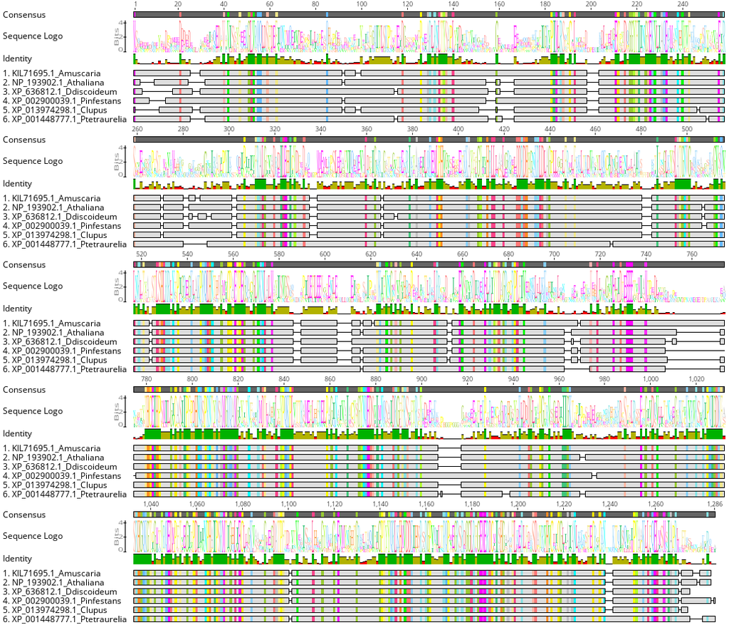

Multiple sequence alignment associated to OG0008354*

The MSA statistics show that this protein family has 366 (28.5%) identical sites, with a pairwise Identity: of 56.0%. So its quite the conserved gene across the eukaryotic tree of life.

#### Questions (Section 4 - **Single copy orthologs**):

1. What are the other functions of the other single copy OG?
2. Are the other single copy OG more or less conserved phylogenetically than OG0008354?

### The **Species tree**

The **Species Tree** is the phylogenetic reconstruction of the species used in this orthology analysis. How is it calculated? According to [Emms and Kelly, 2019](https://genomebiology.biomedcentral.com/articles/10.1186/s13059-019-1832-y):

> OrthoFinder infers orthologs from the orthogroup trees (a gene tree for the orthogroup) using the steps shown in Fig. 2. Input proteomes are provided by the user using one FASTA file per species. Each file contains the amino acid sequences for the proteins in that species. Orthogroups are inferred using the original OrthoFinder algorithm [10]; an unrooted gene tree is inferred for each orthogroup using DendroBLAST [24]; the unrooted species tree is inferred from this set of unrooted orthogroup trees using the STAG algorithm [33]; this STAG species tree is then rooted using the STRIDE algorithm by identifying high-confidence gene duplication events in the complete set of unrooted orthogroup trees [22]; the rooted species tree is used to root the orthogroup trees; orthologs and gene duplication events are inferred from the rooted orthogroup trees by a novel hybrid algorithm that combines the “species-overlap” method [31] and the duplication-loss-coalescent model [32] (described below); and comparative statistics are calculated.

So, how does the species tree look? We can find it at `~/orthofinder_test/OrthoFinder/Results_Feb06_1/Species_Tree/SpeciesTree_rooted.txt`. We can open it on R:

```r
library(ggtree)
```

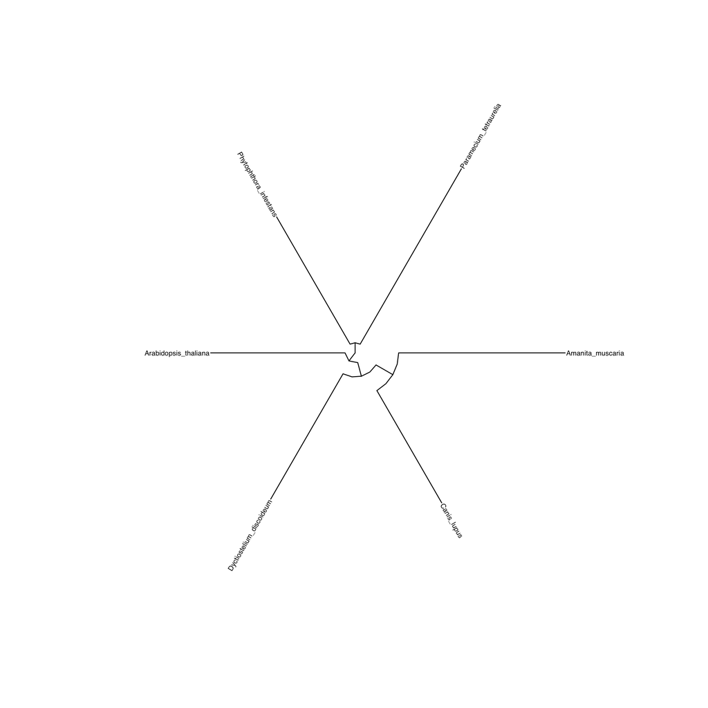

```r
species.tree <- read.tree("Results/SpeciesTree_rooted.txt.tre")

ggtree(species.tree, layout = "circular") + geom_tiplab2(size=3) + xlim(0, 1)
```

#### Questions (Section 4 - **Species tree**):

1. How does the tree look? Does it make sense biologically?